# Georreferenciación utilizando RSelenium y presentación de resultados utilizando Dashboards

# Paquetes

- tidyverse
- RSelenium
- flexdashboard
- highcharter

# Scraping: ¿qué es?

El *Web scraping* o “raspado web”, es una técnica utilizada mediante programas de software para extraer información de sitios web. Usualmente, estos programas simulan la navegación de un humano en la Web.

### RSelenium

Selenium WebDriver es una herramienta de automatización que imita las acciones y patrones de una persona física que interactúa con una página web. Selenium se usa comúnmente en la industria de la Tecnología de la Información para automatizar las pruebas de las funcionalidades del sistema antes de su implementación.  
RSelenium es un paquete construido en base a Selenium WebDriver.

### HTML y CSS

Para extraer información de una página web mediante el scraping es imprescindible conocer su estructura. Para ello debemos tener conocimientos básicos de [HTML](https://www.w3schools.com/html/default.asp) y [CSS](https://www.w3schools.com/css/default.asp).

Los *elementos* son objetos que hacen a la estructura de la página web. Para este caso, reconoceremos:

- div
- input
- button
- ul
- li

Para poder identificar uno o varios elementos en particular, podemos hacer uso de los *atributos* de cada elemento. Nosotros usaremos los siguientes:

- class
- id
- hidden-value

## Manos a la obra

### Abrir un navegador usando RSelenium

```r
# Setup Selenium Driver ####
# install.packages("RSelenium")
library(RSelenium)
```

```r
###################################
### RSelenium con Mozilla Firefox
###################################
rD = rsDriver(browser = "firefox",
              geckover = "0.25.0")
remDr <- rD[["client"]]
# binman::list_versions("geckodriver")
```

```r
#################################
### RSelenium con Google Chrome
#################################

# Start Selenium server and browser
rD <- RSelenium::rsDriver(verbose = F,browser = "chrome",
                          chromever =
                            system2(command = "wmic",
                                    args = 'datafile where name="C:\\\\Program Files (x86)\\\\Google\\\\Chrome\\\\Application\\\\chrome.exe" get Version /value',
                                    stdout = TRUE,
                                    stderr = TRUE) %>%
                            stringr::str_extract(pattern = "(?<=Version=)\\d+\\.\\d+\\.\\d+\\.") %>%
                            magrittr::extract(!is.na(.)) %>%
                            stringr::str_replace_all(pattern = "\\.",
                                                     replacement = "\\\\.") %>%
                            paste0("^",  .) %>%
                            stringr::str_subset(string =
                                                  binman::list_versions(appname = "chromedriver") %>%
                                                  dplyr::last()) %>%
                            as.numeric_version() %>%
                            max() %>%
                            as.character())
# Assign the client to an object
remDr <- rD[["client"]]
```

### Objetivo

Queremos automatizar la búsqueda de coordenadas planas de una lista de direcciones. Para esto podemos ayudarnos de RSelenium. Para conseguirlo, debemos escribir un código que nos permita:

1. Navegar hasta Infomapa
2. Encontrar la caja de búsqueda en la estructura de la página:

Buscaremos el elemento <input>, es decir, el campo que permite al usuario ingresar caracteres, que corresponda con la caja de búsqueda; y obtendremos un atributo con el que se lo pueda identificar de manera única.

3. Emular una consulta:

Escribiremos un código de R que pegue una dirección en la caja de búsqueda identificada anteriormente y daremos click en el botón de buscar. El de búsqueda es un elemento <button>; de igual manera que antes busqueremos un atributo con el cual poder identificarlo.

4. Encontrar las coordenadas del resultado de la búsqueda en la estructura de la página:

En caso de que la búsqueda haya sido exitosa, recobraremos las coordenadas para cada dirección y las almacenaremos en una variable.

### Interacción con Infomapa

Una por una, se buscan las direcciones de la lista y se extraen las coordenadas correspondientes:

```r
  for (i in 1:nrow(direcciones)){
 # for (i in 1:1){

      tryCatch({
     remDr$navigate("http://infomapa.rosario.gov.ar/emapa/mapa.htm")

#El cuadro de input de direcciones es
webElem <- remDr$findElement(using = 'id', value = "txtDireccionesLugares")

webElem$sendKeysToElement(list(direcciones$DIRECCION[i]))

SearchBut <- remDr$findElement(using = 'id', value = "txtDireccionesLugares-boton-search")
SearchBut$clickElement()
Sys.sleep(2)

#Busco las coordenadas dentro del codigo HTML y las guardo en un objeto
a =  remDr$findElement(using = "class", value = "ubicaciones-li")

coords = as.character(a$getElementAttribute("hidden-value"))

if(length(coords)>0){
Inicio <- str_locate(coords, "coordinates':")
Fin <- str_locate_all(coords, "]")

Coords = if(grepl("coordinates",coords)){ str_sub(coords,Inicio[2]+2,max(unlist(Fin))-1)}

X_Y = separate(data.frame(Coords),Coords,c("X","Y"),",")
  direcciones$X[i] = X_Y$X
  direcciones$Y[i] = X_Y$Y

}
},error = function(e){})
  }
```

[output not shown]

```
##                  DIRECCION                 X                 Y
## 1            San Luis 2020 5439081.847419366 6354948.336701104
## 2                1739 7691  5432071.41151111 6353919.469233154
## 3            Amenabar 4122 5435868.598640272 6352929.656446422
## 4         Juan J Paso 2010  5435295.83690355 6357937.770420098
## 5  Avellaneda 4513 letra d  5435649.08339881 6350472.454631846
## 6       Casiano Casas 1801 5433811.588799148 6359897.296579856
## 7        Burucuya 929 BIS   5433131.32655919 6358064.379711052
## 8       Olavarria 1350 bis              <NA>              <NA>
## 9           Abeyaneda 5625              <NA>              <NA>
## 10          Aveyaneda 5625   5435642.8630187 6348622.890926392
## 11         Abellaneda 5625   5435642.8630187 6348622.890926392
```

### Limitaciones

- Errores de tipeo
- Atado a la actualización del Infomapa
- Imposibilidad de usar R mientras esté funcionando el scraping

# Presentación de resultados: Dashboard

Se puede utilizar R Markdown para publicar visulizaciones de datos como dashboard. Para esto utiliza un paquete llamado **flexdashboard**

```r
install.packages("flexdashboard")
```

Para crear un dashboard de manera sencilla podemos seleccionar Flex Dashboard desde un template

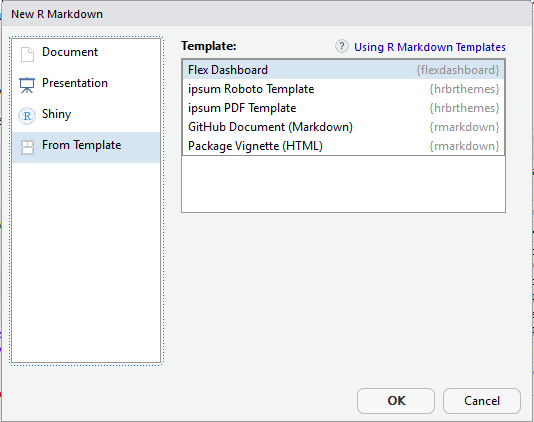

El encabezado deberia ser similar a este:

```r
---
title: 'Panel de control dengue'
output:
  flexdashboard::flex_dashboard:
    vertical_layout: scroll
---
```

Se pueden agregar opciones para modificar el [theme](https://rmarkdown.rstudio.com/flexdashboard/using.html#themes), agregar una nota al pie, etc.

## Opciones de diseño

### Páginas

Para crear más de una página en un dashboard usamos (==================). Cada página tiene su propia pestaña en la parte superior del dahboard.

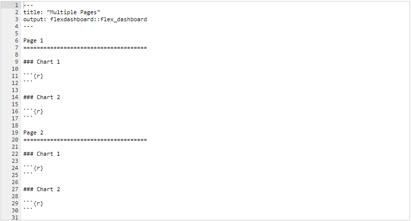

### Orientación

Cada página debe tener una orientación, esto indica si los gráficos que agregemos se ordenan en filas o columnas. Por default cada separacion del estilo (——————) define a una columna en una página. Se puede indicar que sean filas agregando **orientation: rows** en el encabezado o **{data-orientation=rows}** cuando definimos una página. En una misma página no podemos crear filas y columnas al mismo tiempo.

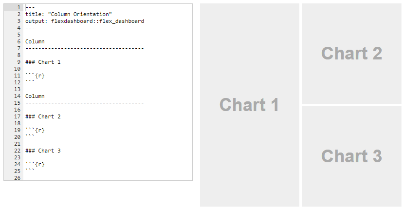

### Pestañas

Si hay varios graficos para que no queden muy chicos se pueden agregar pestañas dentro de las columnas o filas con la opción **{.tabset}**. Si se usa **{.tabset .tabset-fade}** se agrega un efecto de transición de desvanecimiento.

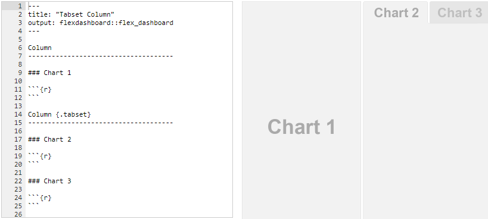

### Ajustar tamaño

El ancho de los gráficos depende del browser. Si solo hay una columna esta ocupara completamente el browser. Si hay más de una columna, se divide en partes iguales, excepto que se modifique con **data-width** en las filas o cada gráfico.

Con la altura de los gráficos pasa lo mismo y para modificarlo se usa **data-height**

### Icons

Se puede agregar un icono junto a la pestaña de cada página usando **data-icon**, estos pueden venir de tres páginas:

- [Font Awesome](https://fontawesome.com/icons?from=io)
- [Ionicons](https://ionicons.com/)
- [Bootstrap Glyphicons](https://getbootstrap.com/docs/4.5/components/alerts/)

### Barra de navegación

En la barra de navegación del dashboard por default se incluye el titulo, nombre del autor y fecha del documento. Además, si se crearon varias páginas se incluye una pestaña para cada una. Algunos detalles que se pueden agregar son un logo con la opción **logo**, links con la opción **navbar**, link para compartir el dashboard en alguna red social con la opción **social** o un link al código con el que se creo el dashboard con la opción **source_code**. Un encabezado mas completo se veria:

```r
---
title: 'Panel de control dengue'
output:
  flexdashboard::flex_dashboard:
    vertical_layout: scroll
    logo: logo.png
    navbar:
        - { title: "Mas información", href: "www.google.com", align: left } #Tambien se puede agregar un icono
    social: [ "twitter", "facebook", "linkedin"]
    source_code: embed #Tambien se puede agregar directamente el link a github
---
```

## Gráficos

### Highcharter

Highcharter es un paquete de R para crear gráficos dinámicos de Highcharts que utilizan internamente javascript.

Hay funciones que tiene un comportamiento similar a las del paquete ggplot2: **hchart** es similar a qplot, **highchart** a ggplot, **hc_add_series** a geom_S y **hcaes** a aes.

Permite generar varios tipos de gráficos con el mismo estilo y un código similar: dispersión, burbuja, línea, serie de tiempo, mapas de calor, treemap, gráficos de barras, redes, etc.

Permite agregar movimiento, font-awesome, tooltips, anotaciones entre otros.

```r
library(highcharter)
#Arreglar
highchart()%>%
  hc_add_series(Star_wars, "columns", hcaes(x = Planeta, y = Frecuencia))
```

### Value Box

Son muy utiles para destacar algun valor junto con un título y un icono, este último es opcional.

```r
valueBox(value = nrow(star_wars) ,icon = "fa-user",caption = "N° de personajes",color = "red")
```

### Tablas

Se pueden agregar tablas estandar que se crean con el paquete kable o se puede usar el paquete DT. Este ultimo permite crear tablas mas interactivas que se pueden ordenar, filtrar y separar en páginas.

```r
datatable(star_wars, filter= "top", class = "cell-border stripe")
```

## Algunos links

- [Sitio oficial de Flexdashboard](https://rmarkdown.rstudio.com/flexdashboard/index.html)
- [Algunos ejemplos](https://rmarkdown.rstudio.com/flexdashboard/examples.html)